# Predict Number of Future Elk Hunters

Pierre Sarnow

Wed Oct 3 11:19:38 2018

## Description

Use historical draw results, and number of hunters to train a model we can use to predict the number of hunters in future years.

TODO - Include other potential inputs that could impact how many hunters get a license and show up. Those could include economic indicators, and costs associated with hunting (transportation, lodging).

**NOTICE** that I am only looking at the general rifle hunting seasons on public land. There are also hunters for Archery, Muzzleloader, Private Land, Ranching for Wildlife, etc.

## Setup

Load required libraries for wrangling data, charting, and mapping

```r
library(plyr,quietly = T) # data wrangling
library(dplyr,quietly = T) # data wrangling
library(ggplot2, quietly = T) # charting
library(ggthemes,quietly = T) # so I can add the highcharts theme and palette
library(scales,quietly = T) # to load the percent function when labeling plots
library(caret,quietly = T) # classification and regression training
library(foreach,quietly = T) # parallel processing to speed up the model training
library(doMC,quietly = T) # parallel processing to speed up the model training
library(lubridate,quietly = T) # for timing models
```

Set our preferred charting theme

```r
theme_set(theme_minimal()+theme_hc()+theme(legend.key.width = unit(1.5, "cm")))
```

Run script to get hunter data

```r
source('~/_code/colorado-dow/datasets/Colorado Elk Harvest Data.R', echo=F)
```

Table of the harvest data

```r
COElkRifleAll
```

| Unit | Harvest.Antlered | Hunters.Antlered | Success.Antlered | Season | HuntCode | Harvest.Antlerless | Hunters.Antlerless | Success.Antlerless | Hunters.Either | Success.Either | Year |
| --- | --- | --- | --- | --- | --- | --- | --- | --- | --- | --- | --- |
| 1 | 0 | 0 | NA | 1 | EM001O1R | NA | NA | NA | NA | NA | 2006 |
| 2 | 0 | 0 | NA | 1 | EM002O1R | NA | NA | NA | NA | NA | 2006 |
| 201 | 0 | 0 | NA | 1 | EM201O1R | NA | NA | NA | NA | NA | 2006 |
| 3 | 0 | 0 | NA | 1 | EM003O1R | NA | NA | NA | NA | NA | 2006 |
| 301 | 0 | 0 | NA | 1 | EM301O1R | NA | NA | NA | NA | NA | 2006 |
| 4 | 0 | 0 | NA | 1 | EM004O1R | NA | NA | NA | NA | NA | 2006 |
| 441 | 0 | 0 | NA | 1 | EM441O1R | NA | NA | NA | NA | NA | 2006 |
| 5 | 0 | 0 | NA | 1 | EM005O1R | NA | NA | NA | NA | NA | 2006 |
| 6 | 0 | 0 | NA | 1 | EM006O1R | NA | NA | NA | NA | NA | 2006 |
| 7 | 18 | 210 | 9 | 1 | EM007O1R | NA | NA | NA | NA | NA | 2006 |

[output cut: 9990 more lines]

Run script to get draw data

```r
source('~/_code/colorado-dow/datasets/Elk Drawing Summaries.R', echo=F)
```

Table of the data

```r
COElkDrawAll
```

| HuntCode | Orig_Quota | Ttl_Chce_1 | Chcs_Drawn | Sex | Unit | Season | Year | Draw_Success |
| --- | --- | --- | --- | --- | --- | --- | --- | --- |
| EE003O1R | 1075 | 2188 | 1075 | Either | 3 | 1 | 2006 | 0.49131627 |
| EE003O4R | 300 | 533 | 300 | Either | 3 | 4 | 2006 | 0.56285178 |
| EE004O4R | 150 | 235 | 150 | Either | 4 | 4 | 2006 | 0.63829787 |
| EE005O4R | 10 | 33 | 10 | Either | 5 | 4 | 2006 | 0.30303030 |
| EE006O1R | 100 | 168 | 100 | Either | 6 | 1 | 2006 | 0.59523810 |
| EE006O4R | 80 | 83 | 80 | Either | 6 | 4 | 2006 | 0.96385542 |
| EE011O1R | 4500 | 5073 | 4500 | Either | 11 | 1 | 2006 | 0.88704908 |
| EE011O4R | 420 | 533 | 420 | Either | 11 | 4 | 2006 | 0.78799250 |
| EE012O4R | 445 | 472 | 445 | Either | 12 | 4 | 2006 | 0.94279661 |
| EE014O1R | 75 | 204 | 75 | Either | 14 | 1 | 2006 | 0.36764706 |

[output cut: 6387 more lines]

```r
source('~/_code/colorado-dow/datasets/Colorado GMUnit and Road data.R', echo=F)
```

Take a peak at the boundary data

```r
head(Unitboundaries2)
```

|  | id | long | lat | order | hole | piece | group | COUNTY | DEERDAU | ELKDAU | ANTDAU | MOOSEDAU | BEARDAU | LIONDAU | SQ_MILES | ACRES | SHAPE_area | SHAPE_len | Unit |
| --- | --- | --- | --- | --- | --- | --- | --- | --- | --- | --- | --- | --- | --- | --- | --- | --- | --- | --- | --- |
| 1 | 1 | -109.0486 | 40.83476 | 1 | FALSE | 1 | 1.1 | MOFFAT | D-1 | E-47 | A-11 | M-99 | B-15 | L-1 | 127.2227 | 81422.53 | 329506619 | 100751.7 | 1 |
| 2 | 1 | -109.0472 | 40.83357 | 2 | FALSE | 1 | 1.1 | MOFFAT | D-1 | E-47 | A-11 | M-99 | B-15 | L-1 | 127.2227 | 81422.53 | 329506619 | 100751.7 | 1 |
| 3 | 1 | -109.0460 | 40.83295 | 3 | FALSE | 1 | 1.1 | MOFFAT | D-1 | E-47 | A-11 | M-99 | B-15 | L-1 | 127.2227 | 81422.53 | 329506619 | 100751.7 | 1 |
| 4 | 1 | -109.0449 | 40.83228 | 4 | FALSE | 1 | 1.1 | MOFFAT | D-1 | E-47 | A-11 | M-99 | B-15 | L-1 | 127.2227 | 81422.53 | 329506619 | 100751.7 | 1 |
| 5 | 1 | -109.0438 | 40.83204 | 5 | FALSE | 1 | 1.1 | MOFFAT | D-1 | E-47 | A-11 | M-99 | B-15 | L-1 | 127.2227 | 81422.53 | 329506619 | 100751.7 | 1 |
| 6 | 1 | -109.0423 | 40.83181 | 6 | FALSE | 1 | 1.1 | MOFFAT | D-1 | E-47 | A-11 | M-99 | B-15 | L-1 | 127.2227 | 81422.53 | 329506619 | 100751.7 | 1 |

Set to predictive analytics directory

```r
setwd("~/_code/colorado-dow/phase III - predictive analytics")
```

## Organize data

Will start by grouping all of the seasons together, and modeling the number of hunters per Year and Unit Group Draw results data by Year and Unit

```r
COElkDraw <- summarise(group_by(COElkDrawAll,Year,Unit),
                       Quota = sum(Orig_Quota,na.rm = T),
                       Drawn = sum(Chcs_Drawn,na.rm = T))
```

Appropriate field classes for model training

```r
COElkDraw$Year <- as.numeric(COElkDraw$Year)
```

Group Hunter data by Year and Unit

```r
COElkHunters <- summarise(group_by(COElkRifleAll,Year,Unit),
                          Hunters = sum(c(Hunters.Antlered,Hunters.Antlerless,Hunters.Either),na.rm = T))

COElkHunters$Year <- as.numeric(COElkHunters$Year)
```

Join in Hunter and Draw data together

```r
COElkHunters <- left_join(COElkHunters, COElkDraw, by = c("Year","Unit"))
```

Replace the draw data that don’t have entries with 0

```r
COElkHunters$Drawn[is.na(COElkHunters$Drawn)] <- 0
COElkHunters$Quota[is.na(COElkHunters$Quota)] <- 0
```

Split into train and test sets. Will use 75% of the data to train on. Be sure to include each unit in the split. … so do the split for each unit, first make sure each Unit has at least three entries

```r
COElkHunters <- mutate(group_by(COElkHunters,Unit),
                       numentries = n())
COElkHunters <- filter(COElkHunters, numentries >= 3)
COElkHunters$UnitYear <- paste(COElkHunters$Unit, COElkHunters$Year)

traindata <- COElkHunters %>% group_by(Unit) %>% sample_frac(size = .75, replace = F)
testdata <- COElkHunters[!COElkHunters$UnitYear %in% traindata$UnitYear,]

COElkHunters <- select(COElkHunters, -UnitYear, -numentries)

traindata <- select(traindata, -UnitYear, -numentries)
testdata <- select(testdata, -UnitYear, -numentries)
```

Save off for importing into AzureML

```r
write.csv(COElkHunters,file = "~/_code/colorado-dow/datasets/COElkHunters.csv",row.names = F)
```

notice that the number of hunters data is skewed.

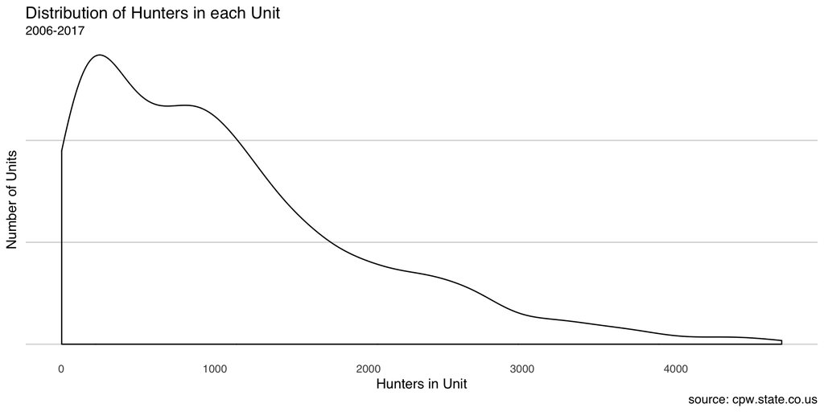

```r
ggplot(COElkHunters, aes(Hunters)) +
  geom_density() +
  xlab("Hunters in Unit") +
  ylab("Number of Units") +
  theme(axis.text.y = element_blank()) +
  labs(title="Distribution of Hunters in each Unit", subtitle="2006-2017", caption="source: cpw.state.co.us")
```

A general rule of thumb to consider is that skewed data whose ratio of the highest value to the lowest value is greater than 20 have significant skewness. Also, the skewness statistic can be used as a diagnostic. If the predictor distribution is roughly symmetric, the skewness values will be close to zero. As the distribution becomes more right skewed, the skewness statistic becomes larger. Similarly, as the distribution becomes more left skewed, the value becomes negative. Replacing the data with the log, square root, or inverse may help to remove the skew. Example of how BoxCox can redistribute the data

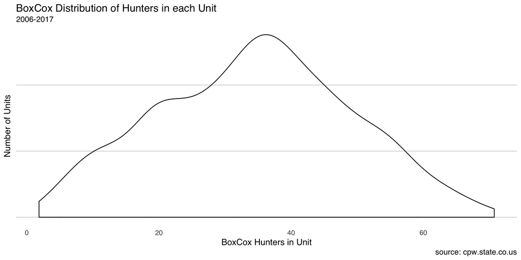

```r
preProcValues2 <- preProcess(as.data.frame(traindata), method = "BoxCox")
trainBC <- predict(preProcValues2, as.data.frame(traindata))

ggplot(trainBC, aes(Hunters)) +
  geom_density() +
  xlab("BoxCox Hunters in Unit") +
  ylab("Number of Units") +
  theme(axis.text.y = element_blank()) +
  labs(title="BoxCox Distribution of Hunters in each Unit", subtitle="2006-2017", caption="source: cpw.state.co.us")
```